# Modelos de Regresión Lineal

Javier Carpio & Paul Belches

19/3/2020

## Regresión Lineal Multiple

De igual manera que en la hoja de trabajo anterior, las variables a utilizar para la creación de los modelos son:

```
      * GarageYrBlt
      * GrLivArea
      * X1stFlrSF
      * GarageCars
      * X2ndFlrSF
```

Así que para mantener una sincronía en el análisis, se utilizarán las mismas variables para poder comparar los resultados.

### Prediciendo SalePrice a partir de las demas variables

#### Conjuntos de entrenamiento y prueba.

Filtramos las variables que sean numéricas para analizar su comportamiento.

```r
porcentaje<-0.7
datos<-read.csv("train.csv")
datosFilter <-select(datos, GarageYrBlt, GrLivArea, X1stFlrSF, X2ndFlrSF, GarageCars, SalePrice)

#Data cleanup
datosFilter <- na.omit(datosFilter)
```

Se separa el dataset a uno de train y otro de test. Ademas, de las variables antes mencionadas, se quitó X2ndFlrSF pues no tiene una alta correlación.

```r
set.seed(123)

corte <- sample(nrow(datosFilter),nrow(datosFilter)*porcentaje)
train<-datos[corte,]
train <-select(datosFilter, GarageYrBlt, GrLivArea, X1stFlrSF, GarageCars, SalePrice)


test<-datos[-corte,]
test <-select(test, GarageYrBlt, GrLivArea, X1stFlrSF, GarageCars, SalePrice)
```

Vamos a hacer un modelo para predecir el precio de la casa con las variables numéricas que son numéricas:

```r
fitMLM_Price<-lm(SalePrice~., data = train)
```

El resumen del modelo:

```r
summary(fitMLM_Price)
```

```
##
## Call:
## lm(formula = SalePrice ~ ., data = train)
##
## Residuals:
##     Min      1Q  Median      3Q     Max
## -476580  -20144   -1620   19008  287985
##
## Coefficients:
##               Estimate Std. Error t value Pr(>|t|)
## (Intercept) -1.377e+06  1.188e+05 -11.590   <2e-16 ***
## GarageYrBlt  6.879e+02  6.127e+01  11.228   <2e-16 ***
## GrLivArea    6.759e+01  2.986e+00  22.631   <2e-16 ***
## X1stFlrSF    4.265e+01  3.894e+00  10.952   <2e-16 ***
## GarageCars   2.556e+04  2.723e+03   9.389   <2e-16 ***
## ---
## Signif. codes:  0 '***' 0.001 '**' 0.01 '*' 0.05 '.' 0.1 ' ' 1
##
## Residual standard error: 45250 on 1374 degrees of freedom
## Multiple R-squared:  0.6731, Adjusted R-squared:  0.6721
## F-statistic: 707.2 on 4 and 1374 DF,  p-value: < 2.2e-16
```

Es posible que exista multicolinealidad entre las variables predictoras. Revisemos eso…

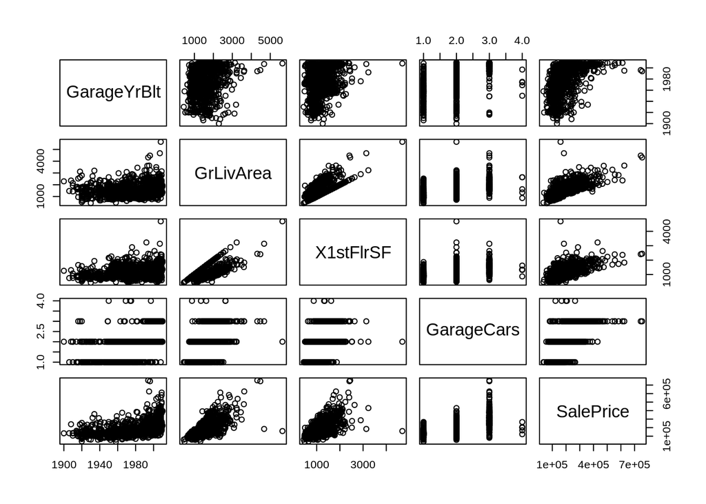

```r
plot(train)
```

```r
matriz_cor <- cor(train)
matriz_cor
```

```
##             GarageYrBlt GrLivArea X1stFlrSF GarageCars SalePrice
## GarageYrBlt   1.0000000 0.2311967 0.2334491  0.5889200 0.4863617
## GrLivArea     0.2311967 1.0000000 0.5546201  0.4838987 0.7081721
## X1stFlrSF     0.2334491 0.5546201 1.0000000  0.4397398 0.5949353
## GarageCars    0.5889200 0.4838987 0.4397398  1.0000000 0.6370954
## SalePrice     0.4863617 0.7081721 0.5949353  0.6370954 1.0000000
```

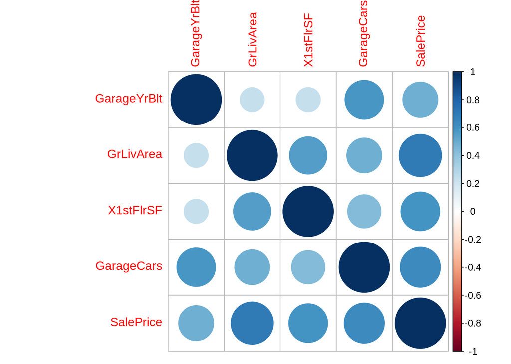

```r
corrplot(matriz_cor)
```

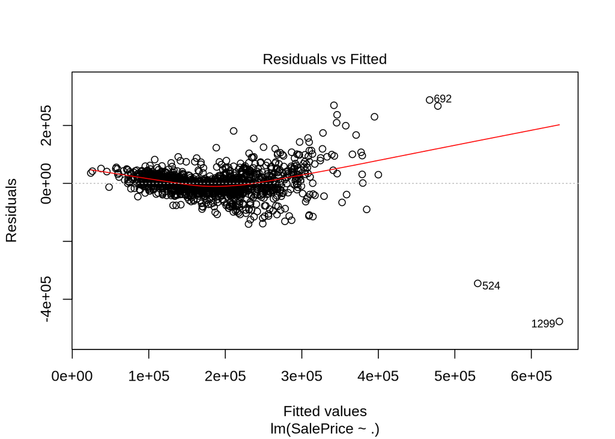

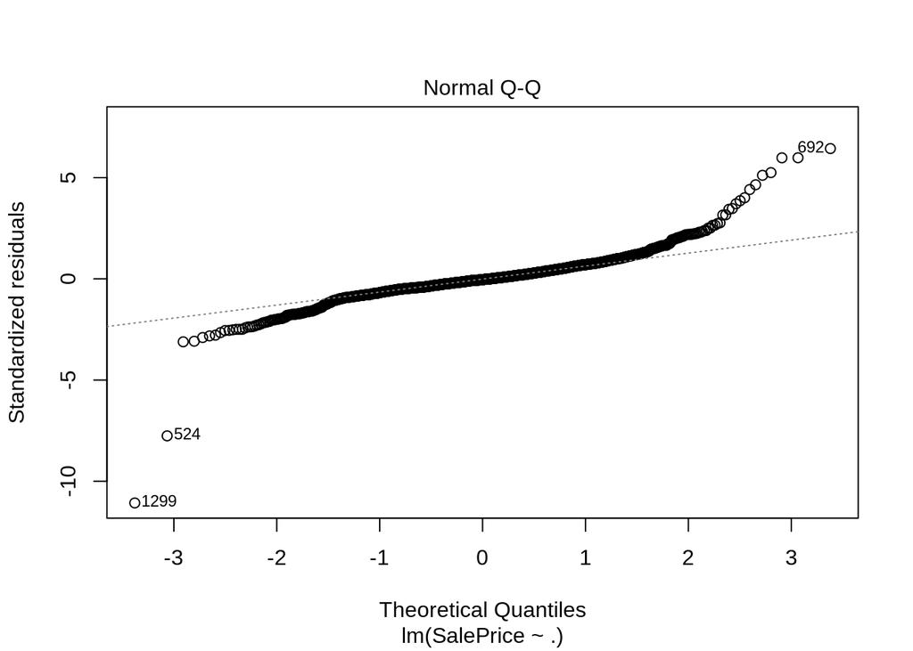

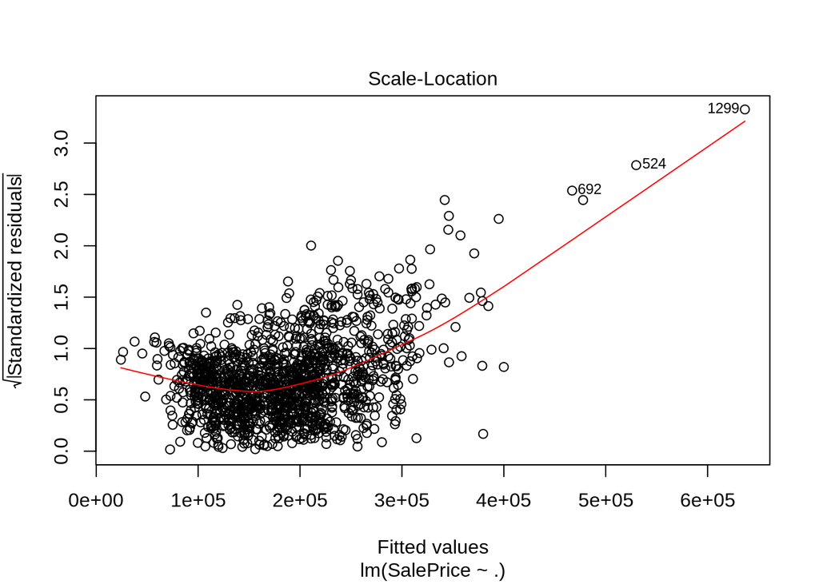

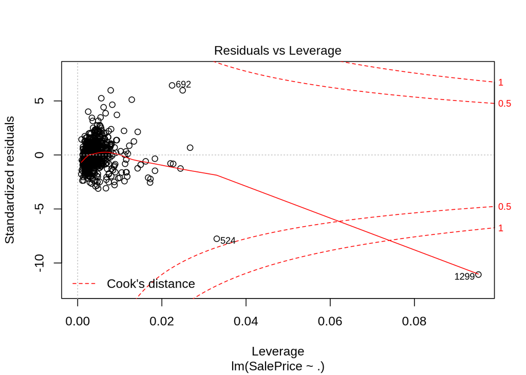

```r
plot(fitMLM_Price)
```

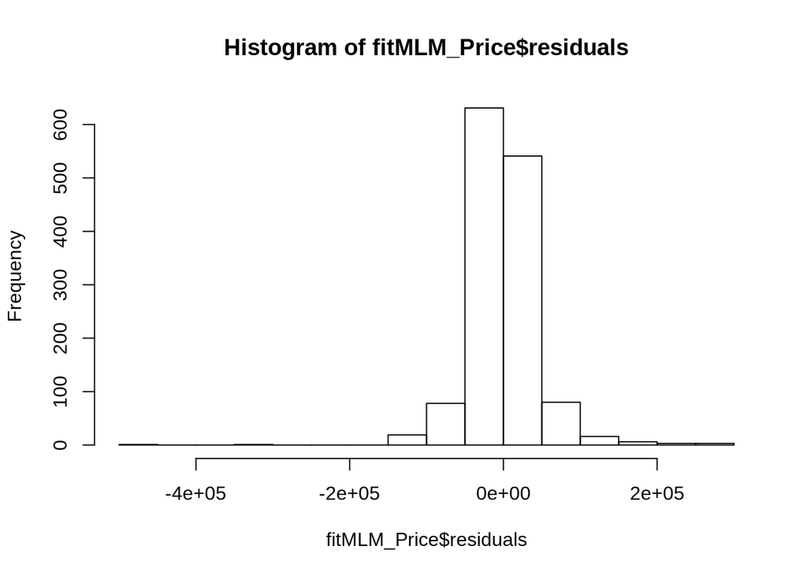

```r
hist(fitMLM_Price$residuals)
```

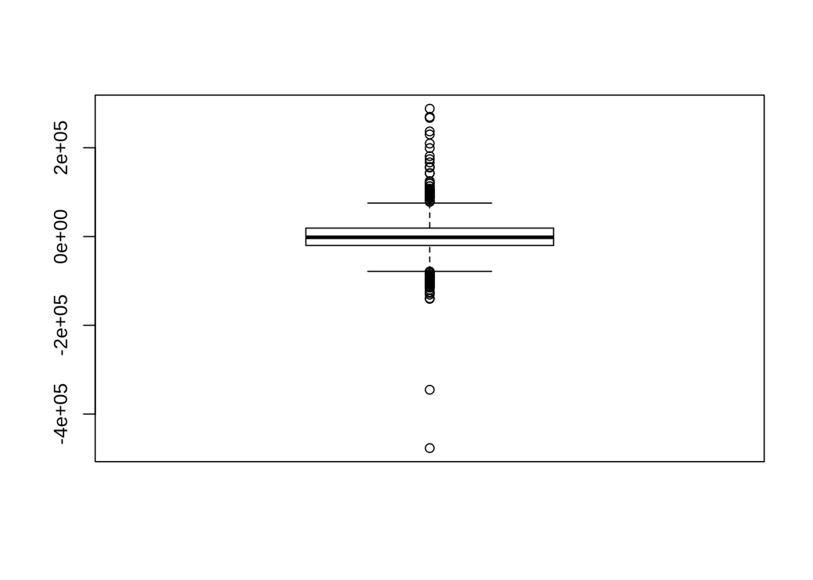

```r
boxplot(fitMLM_Price$residuals)
```

La prueba de lilliefors da como resultado que se rechaza la hipotesis de normalidad, es decir, los residuales no se comportan de forma normal.

```r
lillie.test(fitMLM_Price$residuals)
```

```
##
##  Lilliefors (Kolmogorov-Smirnov) normality test
##
## data:  fitMLM_Price$residuals
## D = 0.096124, p-value < 2.2e-16
```

Es posible que el modelo no sea tan bueno para predecir, pero veremos gráficamente y analíticamente cómo se comporta.

```r
predMLM<-predict(fitMLM_Price, newdata = test)
RMSE(predMLM, test$SalePrice, na.rm = TRUE) #Error medio cuadrático
```

```
## [1] 46734.2
```

Vemos que el Error cuadrático medio es es muy alto… Si ploteamos los datos predichos contra los reales:

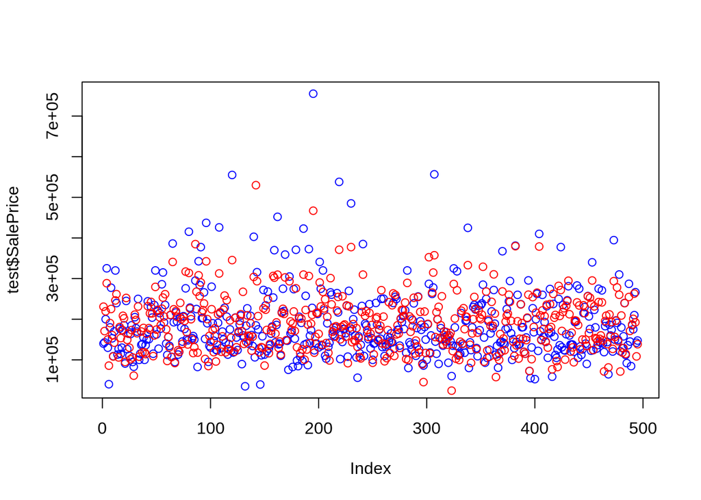

```r
plot(test$SalePrice,col="blue")
points(predMLM, col="red")
```

Vemos que el modelo se aproxima a los resultados y predice exactamente a algunos valores reales, sin embargo para valores muy alto o bajo (valores atípico) no los predice correctamente.

La ecuación quedaría de la siguiente forma:

```r
fitMLM_Price
```

```
##
## Call:
## lm(formula = SalePrice ~ ., data = train)
##
## Coefficients:
## (Intercept)  GarageYrBlt    GrLivArea    X1stFlrSF   GarageCars
##  -1.377e+06    6.879e+02    6.759e+01    4.265e+01    2.556e+04
```

$SalePrice = -1.377213\times 10^{6} + 687.86*GarageYrBlt + 67.59*GrLivArea + 42.65* X1stFlrSF + 2.556428\times 10^{4}* GarageCars$

Ahora, analicemos, ¿qué pasa con árboles de regresión?

```r
houses <- read.csv("train.csv")
housesFilter <-select(houses, LotFrontage, LotArea, YearBuilt, YearRemodAdd, MasVnrArea, BsmtFinSF1,BsmtFinSF2,BsmtUnfSF,TotalBsmtSF,X1stFlrSF,X2ndFlrSF,LowQualFinSF,GrLivArea,TotRmsAbvGrd,Fireplaces,GarageYrBlt,GarageCars,GarageArea,WoodDeckSF,OpenPorchSF,EnclosedPorch,ScreenPorch,PoolArea,MoSold,SalePrice,YrSold)
```

```r
porciento <- 70/100
set.seed(123)
trainRowsNumber<-sample(1:nrow(housesFilter),porciento*nrow(housesFilter))
train<-housesFilter[trainRowsNumber,]
test<-housesFilter[-trainRowsNumber,]
```

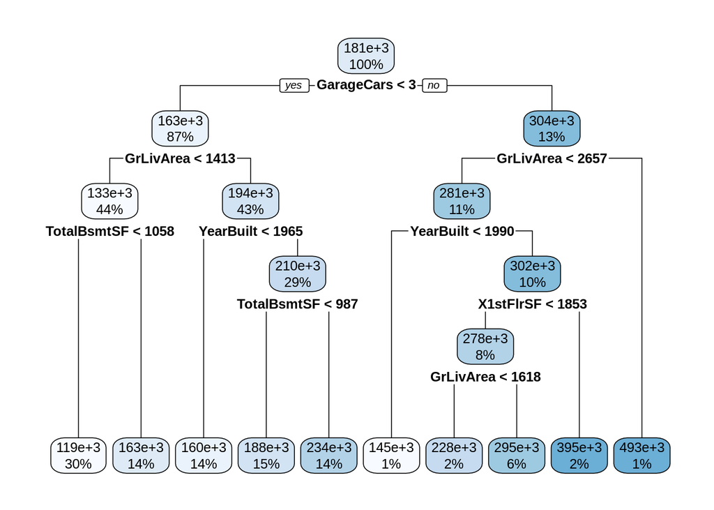

```r
#train$grupo <- mapvalues(train$grupo, c(1,2,3), c("Intermedio","Bajo","Caro"))
dt_model<-rpart(train$SalePrice~.,train,method = "anova")
rpart.plot(dt_model)
```

Al comparar, el conjunto de datos de prueba con el conjunto de datos generados por el árbol optenemos.

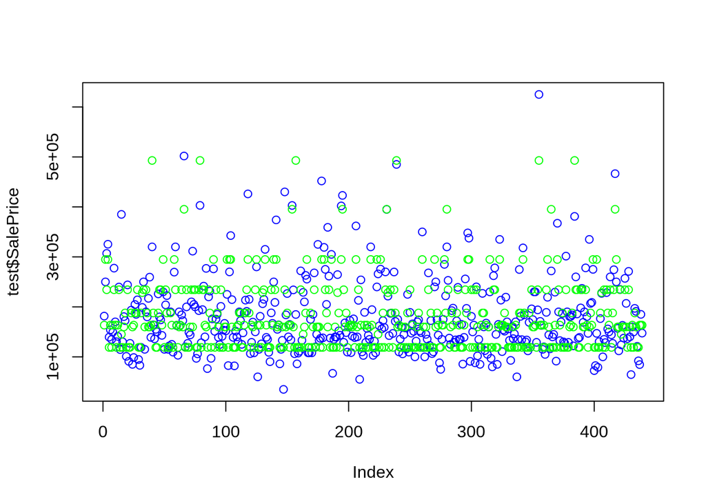

```r
prediccion <- predict(dt_model, newdata = test)
plot(test$SalePrice, col='blue')
points(prediccion, col='green')
```

El modelo cuenta además con un error medio cuadrático de:

```r
RMSE(test$SalePrice, prediccion)
```

```
## [1] 48081.92
```

## En conclusión

En conclusión, basandose en el valor del error medio cuadrático, los modelos son bastante parecidos en lo que respecta a su presición. Sin embargo un análisis gráfico nos muestra que la distribución de puntos del modelo de árbol de regresión está muy categorizado. Los puntos se distribuyen en un patrón observable, dejando valores sin predecir entre cada conjunto; en comparción con su contraparte del modelo de regresión lineal. Es por eso que en lo que respecta a que algoritmo es mejor, se selecciona el modelo de regresión lineal, por la manera en que se encuentran mejor distribuidas las predicciones.